# Package Functions

## Installation

To install the package, please use:

```
library(devtools)
install_github("doomlab/ViSe")
```

This installation will give you the latest version of the package, regardless of status on CRAN.

```r
library(ViSe)
library(cowplot)
library(ggplot2)
library(plotly)
```

## Example

See supplemental document at https://static.cambridge.org/content/id/urn:cambridge.org:id:article:S0007125018002076/resource/name/S0007125018002076sup001.docx

## Calculate effect size

To obtain the estimates and two-tailed 95% confidence intervals on the effect size d scale (via *d* = $M_{difference}$ / $SD_{Total}$, similar to Glass’ $\Delta$), we divided the reported unadjusted and adjusted mean differences for internalising and externalising by the respective standard deviations of the total sample.

```r
internal_unadjusted <- list(
  mean_diff = 3.68,
  lower_diff = 1.73,
  upper_diff = 5.62,
  sd = 8.29
)

internal_adjusted <- list(
  mean_diff = 2.73,
  lower_diff = 0.77,
  upper_diff = 4.69,
  sd = 8.28
)

external_unadjusted <- list(
  mean_diff = 3.72,
  lower_diff = 2.13,
  upper_diff = 5.32,
  sd = 6.81
)

external_adjusted <- list(
  mean_diff = 3.10,
  lower_diff = 1.49,
  upper_diff = 4.71,
  sd = 6.81
)

list_values <- list(internal_unadjusted, internal_adjusted,
                 external_unadjusted, external_adjusted)
list_names <- c("internal_unadjusted", "internal_adjusted",
                 "external_unadjusted", "external_adjusted")
names(list_values) <- list_names

for (i in list_names){
  list_values[[i]][["d"]] <- list_values[[i]][["mean_diff"]] / list_values[[i]][["sd"]]
  list_values[[i]][["lower_d"]] <- list_values[[i]][["lower_diff"]] / list_values[[i]][["sd"]]
  list_values[[i]][["upper_d"]] <- list_values[[i]][["upper_diff"]] / list_values[[i]][["sd"]]
}

unlist(list_values)
```

```
#>  internal_unadjusted.mean_diff internal_unadjusted.lower_diff
#>                     3.68000000                     1.73000000
#> internal_unadjusted.upper_diff         internal_unadjusted.sd
#>                     5.62000000                     8.29000000
#>          internal_unadjusted.d    internal_unadjusted.lower_d
#>                     0.44390832                     0.20868516
#>    internal_unadjusted.upper_d    internal_adjusted.mean_diff
#>                     0.67792521                     2.73000000
#>   internal_adjusted.lower_diff   internal_adjusted.upper_diff
#>                     0.77000000                     4.69000000
#>           internal_adjusted.sd            internal_adjusted.d
#>                     8.28000000                     0.32971014
#>      internal_adjusted.lower_d      internal_adjusted.upper_d
#>                     0.09299517                     0.56642512
#>  external_unadjusted.mean_diff external_unadjusted.lower_diff
#>                     3.72000000                     2.13000000
#> external_unadjusted.upper_diff         external_unadjusted.sd
#>                     5.32000000                     6.81000000
#>          external_unadjusted.d    external_unadjusted.lower_d
#>                     0.54625551                     0.31277533
#>    external_unadjusted.upper_d    external_adjusted.mean_diff
#>                     0.78120411                     3.10000000
#>   external_adjusted.lower_diff   external_adjusted.upper_diff
#>                     1.49000000                     4.71000000
#>           external_adjusted.sd            external_adjusted.d
#>                     6.81000000                     0.45521292
#>      external_adjusted.lower_d      external_adjusted.upper_d
#>                     0.21879589                     0.69162996
```

## Calculate d and Confidence Interval

To visualise the lower level confidence interval *l*, we must obtain the lower bound of the confidence interval for our proposed effect size. ViSe includes a function `calculate_d()` that calculates from `t.test()` output, dataframes, individual vectors of data, sample statistics (*M*, *SD*, *n* for group), *t*-test values, or a pre-calculated *d*-value.

In this example, we have our *d* value from the original research, along with sample sizes from the study which can be used to calculate the two-tailed `dlow_central` or one-tailed `done_low_central` lower confidence interval. The package vignette shows all possible ways to calculate values from data and includes the non-centralized confidence intervals for effect size *d* as well (below).

```r
internal_unadj_output <- calculate_d(
  d = list_values$internal_adjusted$d, # d value
  a = .05, # alpha for confidence interval
  lower = TRUE, # you expect d to be positive
  n1 = 71, # sample size group 1
  n2 = 3653  # sample size group 2
)

internal_unadj_output$dlow_central
```

```
#> [1] 0.09465985
```

```r
internal_unadj_output$done_low_central
```

```
#> [1] 0.1324648
```

```r
# note, the program also provide noncentral t confidence intervals
# in this case, they are unusable because d has been calculated from
# mean difference / control rather than mean difference / spooled
# therefore the approximation of t and the noncentral
# limits is not appropriate
```

### Other Examples of `calculate_d`

```r
# from dataframe
calculate_d(
  df = mtcars,
  x_col = "am",
  y_col = "hp",
  a = .05,
  lower = TRUE
)
```

```
#> $d
#> [1] -0.501465
#>
#> $dlow
#> [1] -1.2067
#>
#> $dhigh
#> [1] 0.2260463
#>
#> $dlow_central
#> [1] -1.247618
#>
#> $dhigh_central
#> [1] 0.2446883
#>
#> $done_low
#> [1] -1.091478
#>
#> $done_low_central
#> [1] -1.121567
#>
#> $M1
#> [1] 126.8462
#>
#> $sd1
#> [1] 84.06232
#>
#> $se1
#> [1] 23.31469
#>
#> $M1low
#> [1] 76.0478
#>
#> $M1high
#> [1] 177.6445
#>
#> $M2
#> [1] 160.2632
#>
#> $sd2
```

[output cut: 22 more lines]

```
#>
#> $df
#> [1] 30
#>
#> $t
#> [1] -1.373318
#>
#> $p
#> [1] 0.1798309
#>
#> $estimate
#> [1] "$d_s$ = -0.50, 95\\% CI [-1.21, 0.23]"
#>
#> $statistic
#> [1] "$t$(30) = -1.37, $p$ = .180"
```

```r
# from two columns
x <- mtcars$am
y <- mtcars$hp

calculate_d(
  x_col = x,
  y_col = y,
  a = .05,
  lower = TRUE
)
```

```
#> $d
#> [1] -0.501465
#>
#> $dlow
#> [1] -1.2067
#>
#> $dhigh
#> [1] 0.2260463
#>
#> $dlow_central
#> [1] -1.247618
#>
#> $dhigh_central
#> [1] 0.2446883
#>
#> $done_low
#> [1] -1.091478
#>
#> $done_low_central
#> [1] -1.121567
#>
#> $M1
#> [1] 126.8462
#>
#> $sd1
#> [1] 84.06232
#>
#> $se1
#> [1] 23.31469
#>
#> $M1low
#> [1] 76.0478
#>
#> $M1high
#> [1] 177.6445
#>
#> $M2
#> [1] 160.2632
#>
#> $sd2
```

[output cut: 22 more lines]

```
#>
#> $df
#> [1] 30
#>
#> $t
#> [1] -1.373318
#>
#> $p
#> [1] 0.1798309
#>
#> $estimate
#> [1] "$d_s$ = -0.50, 95\\% CI [-1.21, 0.23]"
#>
#> $statistic
#> [1] "$t$(30) = -1.37, $p$ = .180"
```

```r
# from summary statistics
calculate_d(m1 = 14.37, # neglect mean
   sd1 = 10.716, # neglect sd
   n1 = 71, # neglect n
   m2 = 10.69, # none mean
   sd2 = 8.219, # none sd
   n2 = 3653, # none n
   a = .05, # alpha/confidence interval
   lower = TRUE) # lower or upper bound
```

```
#> $d
#> [1] 0.4448249
#>
#> $dlow
#> [1] 0.2097233
#>
#> $dhigh
#> [1] 0.6798669
#>
#> $dlow_central
#> [1] 0.2096767
#>
#> $dhigh_central
#> [1] 0.6799731
#>
#> $done_low
#> [1] 0.2475166
#>
#> $done_low_central
#> [1] 0.2474974
#>
#> $M1
#> [1] 14.37
#>
#> $sd1
#> [1] 10.716
#>
#> $se1
#> [1] 1.271755
#>
#> $M1low
#> [1] 11.83356
#>
#> $M1high
#> [1] 16.90644
#>
#> $M2
#> [1] 10.69
#>
#> $sd2
```

[output cut: 22 more lines]

```
#>
#> $df
#> [1] 3722
#>
#> $t
#> [1] 3.712259
#>
#> $p
#> [1] 0.0002084243
#>
#> $estimate
#> [1] "$d_s$ = 0.44, 95\\% CI [0.21, 0.68]"
#>
#> $statistic
#> [1] "$t$(3722) = 3.71, $p$ < .001"
```

```r
# from t-test model
output <- t.test(mtcars$hp ~ mtcars$am, var.equal = TRUE)
n_values <- tapply(mtcars$hp, mtcars$am, length)
calculate_d(
  model = output,
  n1 = unname(n_values[1]),
  n2 = unname(n_values[2]),
  a = .05,
  lower = TRUE
)
```

```
#> $d
#> [1] 0.501465
#>
#> $dlow
#> [1] -0.2260463
#>
#> $dhigh
#> [1] 1.2067
#>
#> $dlow_central
#> [1] -0.2446883
#>
#> $dhigh_central
#> [1] 1.247618
#>
#> $done_low
#> [1] -0.1109204
#>
#> $done_low_central
#> [1] -0.1186368
#>
#> $M1
#> NULL
#>
#> $sd1
#> NULL
#>
#> $se1
#> NULL
#>
#> $M1low
#> NULL
#>
#> $M1high
#> NULL
#>
#> $M2
#> NULL
#>
#> $sd2
```

[output cut: 22 more lines]

```
#>
#> $df
#> [1] 30
#>
#> $t
#> [1] 1.373318
#>
#> $p
#> [1] 0.1798309
#>
#> $estimate
#> [1] "$d_s$ = 0.50, 95\\% CI [-0.23, 1.21]"
#>
#> $statistic
#> [1] "$t$(30) = 1.37, $p$ = .180"
```

```r
# from t-values
calculate_d(
  t = 1.37,
  n1 = unname(n_values[1]),
  n2 = unname(n_values[2]),
  a = .05,
  lower = TRUE
)
```

```
#> $d
#> [1] 0.5002533
#>
#> $dlow
#> [1] -0.2271793
#>
#> $dhigh
#> [1] 1.205462
#>
#> $dlow_central
#> [1] -0.2458469
#>
#> $dhigh_central
#> [1] 1.246353
#>
#> $done_low
#> [1] -0.1120615
#>
#> $done_low_central
#> [1] -0.1198044
#>
#> $M1
#> NULL
#>
#> $sd1
#> NULL
#>
#> $se1
#> NULL
#>
#> $M1low
#> NULL
#>
#> $M1high
#> NULL
#>
#> $M2
#> NULL
#>
#> $sd2
```

[output cut: 22 more lines]

```
#>
#> $df
#> [1] 30
#>
#> $t
#> [1] 1.37
#>
#> $p
#> [1] 0.1808537
#>
#> $estimate
#> [1] "$d_s$ = 0.50, 95\\% CI [-0.23, 1.21]"
#>
#> $statistic
#> [1] "$t$(30) = 1.37, $p$ = .181"
```

## Convert between effect sizes (specification plot)

Not all research studies use *d* as the effect size of interest, and `ViSe` provides functionality to convert between effect sizes. The `other_to_d()` function can be used to convert effect sizes *f*, $f^2$, NNT, *r*, probability of superiority, U1, U2, U3, and proportional overlap into *d*.

```r
other_to_d(nnt = 35)
```

```
#> [1] 0.051
```

All options of `other_to_d()`:

```
f = NULL,
f2 = NULL,
nnt = NULL,
r = NULL,
prob = NULL,
prop_u1 = NULL,
prop_u2 = NULL,
prop_u3 = NULL,
prop_overlap = NULL
```

The effect size *d* value can then be used to visualize all effects and their conversions at once in the `visualize_effects()` function. You can use the percent, color, and font family options to adjust the resulting graph for readability and color scheme.

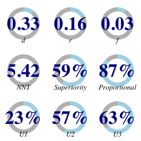

```r
visualize_effects(d = list_values$internal_adjusted$d,
                  circle_color = "lightblue",
                  circle_fill = "gray",
                  percent_color = "darkblue",
                  percent_size = 10,
                  text_color = "black",
                  font_family = "Times")
```

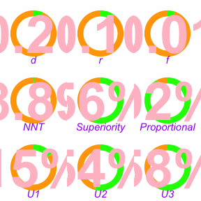

```r
# note graphs look better scaled, try saving them
# ggsave(filename = "visualize_effects.png")

# you can make very ugly graphs if you want
visualize_effects(d = .2,
                  circle_color = "green",
                  circle_fill = "orange",
                  percent_color = "pink",
                  percent_size = 20,
                  text_color = "purple",
                  font_family = "Arial")
```

This package uses the following conversion functions that can be implemented separately as well:

```r
d_to_r(d = list_values$internal_adjusted$d)
```

```
#> [1] 0.1626596
```

```r
d_to_f2(d = list_values$internal_adjusted$d)
```

```
#> $f
#> [1] 0.1648551
#>
#> $f2
#> [1] 0.02717719
```

```r
d_to_nnt(d = list_values$internal_adjusted$d)
```

```
#> [1] 5.424537
```

```r
probability_superiority(d = list_values$internal_adjusted$d)
```

```
#> [1] 0.5921738
```

```r
proportion_overlap(d = list_values$internal_adjusted$d)
```

```
#> $u1
#> [1] 0.2315626
#>
#> $u2
#> [1] 0.565471
#>
#> $u3
#> [1] 0.6291905
#>
#> $p_o
#> [1] 0.8690581
```

## Visualization of sensitivity of effect size to bias

Now that we have an idea of our *d* value, the lower confidence limit *l*, and other potential effect sizes, we can create a sensitivity plot of the effect size to bias. To visualize different *d* values and their representation of the distribution overlap, use `estimate_d()` to examine different effect sizes:

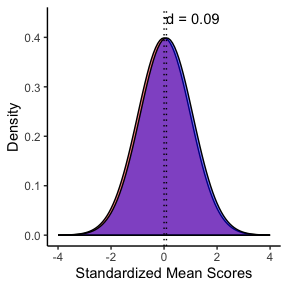

```r
estimate_d(d = .09,
           fill_1 = "red",
           fill_2 = "blue",
           text_color = "black")$graph
```

Similarly, `estimate_r()` shows a scatterplot of the entered correlation coefficient to visualize the relation between two variables:

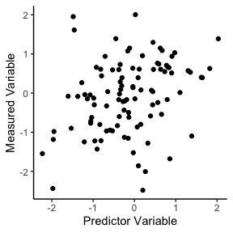

```r
estimate_r(r = .30)$graph
```

You can then use the two estimation functions to create a graph that shows you which combinations of effect size and *r* would indicate a causal effect. You can enter any effect size from our conversion options, and these will be converted to *d* with labels for inspection. The shaded area represents an area that would be considered the effect, and the points represent the entered combination of r and effect size. Points in the shaded area would be considered sensitive to bias.

You can use the `plotly` library to hover over those dots to see their values (also embedded in our shiny app). *Note*: Not run to make this package CRAN compatible (plotly makes html files large).

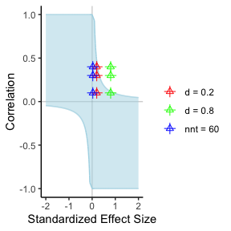

```r
visual_c_mapped <-
  # your lower confidence limit required
  visualize_c_map(dlow = list_values$internal_adjusted$lower_d,
                  # correlation values required
                  r_values = c(.1, .4, .3),
                  # other effect sizes you want to plot
                  d_values = c(.2, .8),
                  nnt_values = c(60),
                  # if you think d will be positive
                  lower = TRUE,
                  # as many values as the max number effects
                  point_colors = c("red", "green", "blue"),
                  # a size for the shapes
                  size = 2,
                  # shape 1
                  shape_1 = 2,
                  # shape 2, make these the same number if you
                  # want the shapes overlapping
                  # we think two different ones helps readability
                  shape_2 = 3,
                  # color of the background highlighted area
                  ribbon_color = "lightblue"
                  )

visual_c_mapped$graph
```

```r
ggsave(filename = "visualize_c_map.png", width = 8,
       height = 6, dpi = 300)

# ggplotly(visual_c_mapped$graph)
```

All options for the graph, including their defaults:

```
visualize_c_map(
  dlow,
  r_values,
  d_values = NULL,
  f_values = NULL,
  f2_values = NULL,
  nnt_values = NULL,
  prob_values = NULL,
  prop_u1_values = NULL,
  prop_u2_values = NULL,
  prop_u3_values = NULL,
  prop_overlap_values = NULL,
  lower = TRUE,
  point_colors = c("red", "green", "blue"),
  size = 2,
  shape_1 = 2,
  shape_2 = 3,
  ribbon_color = "lightblue"
)
```